# Capstone: Initial Analysis on BMW Sales trends in the US

Stephanie Vaul

## Introduction

I’m going to analyze the BMW automotive sales trends in the USA over the last 10 years in order to determine which areas of the country and which models display the highest sales volume and repeat ownership (brand loyalty). In addition, I will try to identify first-time BMW owners and see which model appeal most to them. I will also look at how these trends vary between New and Used vehicles.

My client is BMW North America, a company that my employer has partnered with over the last 10 years to provide customer retention marketing. Determining which model series do well in each geographic area, as well as which series result in repeat buyers will help BMW better focus their marketing efforts for various ad campaigns by leveraging existing trends, as well as being able to extrapolate those trends in other areas of similar makeup.

I plan to use dealership sales data that my company has been collecting for the past 10+ years in order to provide sales-to-service retention marketing, e.g. initial service reminders. This data includes customer and vehicle information, along with the purchase date and type (new vs used). Some of the data includes demographic information, like birth date and gender. I will review the data to see if there is sufficient data in order to provide trend reports based on age &/or gender.

Proprietary sales data from most BMW centers in the U.S. going back 10yrs:

- Region (BMW Region assigned to the selling dealership by BMW, of which there are four)
- Market (BMW Market assigned to the selling dealership by BMW)
- PurchDate
- VehYear
- VehModel
- VehECode (engine code assigned by BMW to categorize years & models)
- TradeVIN
- TradeVehYear
- TradeVehModel
- TradeVehECode
- NewUsed (New, Used, Other sale)
- PurchType (Lease, Cash, Finance)
- Gender (limited data provided here)

BMW also has their own designations for dealership Region and Market. I will apply this similar sorting parameters to the customer’s address in order to determine which Region a customer belongs too. Because we also collect service data, I will be able to also look at how long a customer owned a vehicle by reviewing both Sales and Service data. I will first look to see if we have subsequent sales data on the vehicle – whether that be from another customer purchasing the VIN or the VIN being listed by the same customer as being traded in. If there is no additional sales record, then I can turn to the service history to see when they last serviced it. While this is not entirely accurate should the customer service at an independent station, it will provide better information than not having it at all.

My approach will be to first segment the customers into the various BMW regions, possibly down to the Market level. Their markets are based on BMW locations so this might not be to be extrapolated correctly to all customers. I will then segment out the purchases by model series and type (new or used). I want to be able to see a count of each model series and type for each year overall and within each region. Once top-level exploratory analysis has been performed, I’ll start looking into more details on customer loyalty based on repeat purchases and try to identify which are made by first-time buyers. After that, I will look to see if I can pinpoint the length of ownership for each vehicle to be able to summarize which series are kept by a single owner the longest.

## The Data Set

To get started, let’s set our working directory, clear our Environment, & load our libraries.

```r
setwd("~/_MyFiles/Data Science Workshop/Springboard_DataScientist/Capstone Project")
getwd()
```

```
## [1] "C:/Users/Stephaniev/Documents/_MyFiles/Data Science Workshop/Springboard_DataScientist/Capstone Project"
```

```r
  rm(list=ls())
```

```r
library(devtools)
library(stringr)
library(tidyr)
library(dplyr)
library(ggplot2)
library(scales)
```

Now let’s read in our data set, which contains Dealership, customer, and vehicle sales data for BMW makes. Once read in, we should take a look at the Summary of this table. Since we don’t want to reveal any sensitive data, we won’t look at the head of the table until we’ve been able to reduce the data set to just the fields we need.

```r
Sales <- read.table ("BMWSales.txt", header = TRUE, sep = "|", quote = "\"", stringsAsFactors = FALSE)
```

```r
summary(Sales)
```

```
##      RecNum           BMWDlr           BMWRegion           BMWMarket
##  Min.   :      1   Length:3926804     Length:3926804     Min.   :10.00
##  1st Qu.: 981702   Class :character   Class :character   1st Qu.:16.00
##  Median :1963402   Mode  :character   Mode  :character   Median :26.00
##  Mean   :1963402                                         Mean   :26.47
##  3rd Qu.:2945103                                         3rd Qu.:35.00
##  Max.   :3926804                                         Max.   :48.00
##                                                          NA's   :58157
##     DealerID     DealerName         DealerCity        DealerState
##  Min.   :  12   Length:3926804     Length:3926804     Length:3926804
##  1st Qu.: 898   Class :character   Class :character   Class :character
##  Median :1013   Mode  :character   Mode  :character   Mode  :character
##  Mean   :1024
##  3rd Qu.:1114
##  Max.   :2616
##
##   DealerZip             VINID              VIN                 Year
##  Length:3926804     Min.   :     453   Length:3926804     Min.   :   0
##  Class :character   1st Qu.:10044814   Class :character   1st Qu.:2007
##  Mode  :character   Median :14700210   Mode  :character   Median :2011
##                     Mean   :15005124                      Mean   :2010
##                     3rd Qu.:19612441                      3rd Qu.:2013
##                     Max.   :26057070                      Max.   :2017
##                                                           NA's   :268
##      Make              Model              eCode
##  Length:3926804     Length:3926804     Length:3926804
##  Class :character   Class :character   Class :character
##  Mode  :character   Mode  :character   Mode  :character
##
##
##
##
##    NewUsed           PurchDate           PayType
##  Length:3926804     Length:3926804     Length:3926804
##  Class :character   Class :character   Class :character
##  Mode  :character   Mode  :character   Mode  :character
##
##
##
##
```

[output cut: 41 more lines]

```
##  Length:3926804     Length:3926804     Min.   :    0.00
##  Class :character   Class :character   1st Qu.:    6.00
##  Mode  :character   Mode  :character   Median :   12.00
##                                        Mean   :   74.22
##                                        3rd Qu.:   28.00
##                                        Max.   :10339.00
##                                        NA's   :40333
##     Gender           BirthDate            FixMe
##  Length:3926804     Length:3926804     Length:3926804
##  Class :character   Class :character   Class :character
##  Mode  :character   Mode  :character   Mode  :character
##
##
##
##
```

Now that we can see some information on all the fields, let’s subset the data to eliminate any sales at non-BMW dealerships and remove the unnecessary fields. For example, we don’t need to have any of the customer detail information, such as their name or street address. Since there would be no “New”" BMW sales records at non-BMW dealerships, we can eliminate those records. BMW is our client, so we want to focus on the sales - New or Used - at their dealerships. Once we’ve subset our data, we can take a look at the first few rows.

```r
SalesSub <- subset(Sales, BMWDlr=="True", select = c(BMWRegion, BMWMarket, DealerID, DealerState, VINID, VIN, Year, Make, Model, eCode, PurchDate, NewUsed, PayType, FinanceTerm, PurchasePrice, TradeVINID, TradeVIN, TradeYear, TradeMake, TradeModel, TradeECode, CustID, CustState, Gender, BirthDate) )
```

```r
head(SalesSub)
```

```
##   BMWRegion BMWMarket DealerID DealerState    VINID               VIN Year
## 1   EASTERN        15       40          PA 15698790 5UXZV4C54CL754821 2012
## 2   EASTERN        15       40          PA 15985177 5UXFG2C59CL780025 2012
## 3   EASTERN        15       40          PA  8574341 WBAHL83506DT06209 2006
## 4   EASTERN        15       40          PA 18945332 WBAFU7C52DDU77149 2013
## 5   EASTERN        15       40          PA  8137869 WBAVB735X7P101187 2007
## 6   EASTERN        15       40          PA 18566362 WBA3B9G59DNR79004 2013
##   Make Model        eCode           PurchDate NewUsed PayType
## 1  BMW    X5          E70 2011-08-22 00:00:00       N       C
## 2  BMW    X6          E71 2011-10-07 00:00:00       N       C
## 3  BMW  750i          E65 2012-01-07 00:00:00       U       F
## 4  BMW   535  F07/F10/F11 2013-11-27 00:00:00       N       L
## 5  BMW  335i E90/91/92/93 2007-05-09 00:00:00       N       C
## 6  BMW   335          F30 2013-03-15 00:00:00       N       F
##           FinanceTerm PurchasePrice TradeVINID          TradeVIN TradeYear
## 1 2011-09-22 00:00:00      46875.00         NA                          NA
## 2 2011-11-07 00:00:00      62500.00         NA                          NA
## 3 2017-01-07 00:00:00      27900.00         NA                          NA
## 4 2016-11-27 00:00:00      60745.36    1710225 WBADD6327WGT94406      1998
## 5 2007-06-09 00:00:00      43845.00         NA                          NA
## 6 2016-03-15 00:00:00      51290.00    5838041 WBAVD33546KL52088      2006
##   TradeMake TradeModel   TradeECode CustID CustState Gender BirthDate
## 1                                   378290        PA      M
## 2                                   378290        PA      M
## 3                                   378378        PA      M
## 4       BMW       528i          E39 378408        PA
## 5                                   378425        FL      M
## 6       BMW      330xi E90/91/92/93 378540        PA
```

At this point, it looks like we’ll have an issue with our date fields since they’re currently formatted as characters. We need to set PurchDate, along FinanceTerm and BirthDate, to a date format before we can reduce the data to a 10 year window, in this case, between 1/1/2007 and 12/31/2016. Since the original data file was exported from a SQL database, the date fields were exported out to the millisecond (“2016-12-31 00:00:00.000”) vs just out to the second (“2016-12-31 00:00:00”). Because of this, we need to use the following POSIXct format in order to convert them to a datetime. Once we’ve run the conversion, let’s verify the format is correct.

```r
SalesSub$PurchDate <- as.POSIXct(SalesSub$PurchDate, format = "%Y-%m-%d %H:%M:%OS")
SalesSub$FinanceTerm <- as.POSIXct(SalesSub$FinanceTerm, format = "%Y-%m-%d %H:%M:%OS")
SalesSub$BirthDate <- as.POSIXct(SalesSub$BirthDate, format = "%Y-%m-%d %H:%M:%OS")
```

```r
SalesSub %>%
   summarise(MinPurch = min(PurchDate),MaxPurch = max(PurchDate))
```

```
##     MinPurch   MaxPurch
## 1 2005-01-01 3001-10-30
```

Since our dates look good, let’s go ahead and drop the original Sales table since it’s no longer needed. And we can now use the “PurchDate”" field to further subset our data down to the 10-year range we desire. In this case, let’s just replace the “SalesSub”" table instead of creating a new version. We can then take another look at our minimum and maximum PurchDate range to confirm that it only includes the proper range.

```r
rm(Sales)
```

```r
SalesSub <- subset(SalesSub, as.POSIXct(PurchDate)>=as.POSIXct('2007-01-01 00:00:00.000') & as.POSIXct(PurchDate)<as.POSIXct('2017-01-01 00:00:00.000'), select = c(BMWRegion, BMWMarket, DealerID, DealerState, VINID, VIN, Year, Make, Model, eCode, PurchDate, NewUsed, PayType, FinanceTerm, PurchasePrice, TradeVINID, TradeVIN, TradeYear, TradeMake, TradeModel, TradeECode, CustID, CustState, Gender, BirthDate) )
```

```r
SalesSub %>%
   summarise(MinPurch = min(PurchDate),MaxPurch = max(PurchDate))
```

```
##     MinPurch   MaxPurch
## 1 2007-01-01 2016-12-31
```

Before moving on, let’s convert this data.frame into a dplyr table.

```r
tbl_df(SalesSub)
```

```
## # A tibble: 3,479,515 × 25
##    BMWRegion BMWMarket DealerID DealerState    VINID               VIN
## *      <chr>     <int>    <int>       <chr>    <int>             <chr>
## 1    EASTERN        15       40          PA 15698790 5UXZV4C54CL754821
## 2    EASTERN        15       40          PA 15985177 5UXFG2C59CL780025
## 3    EASTERN        15       40          PA  8574341 WBAHL83506DT06209
## 4    EASTERN        15       40          PA 18945332 WBAFU7C52DDU77149
## 5    EASTERN        15       40          PA  8137869 WBAVB735X7P101187
## 6    EASTERN        15       40          PA 18566362 WBA3B9G59DNR79004
## 7    EASTERN        15       40          PA 11706564 WBAHN835X6DT59882
## 8    EASTERN        15       40          PA 22750487 WBA5A7C58FD628910
## 9    EASTERN        15       40          PA  8839989 WBAVC935X7K035066
## 10   EASTERN        15       40          PA 13795194 WBAPK5C54AA650407
## # ... with 3,479,505 more rows, and 19 more variables: Year <int>,
## #   Make <chr>, Model <chr>, eCode <chr>, PurchDate <dttm>, NewUsed <chr>,
## #   PayType <chr>, FinanceTerm <dttm>, PurchasePrice <dbl>,
## #   TradeVINID <int>, TradeVIN <chr>, TradeYear <int>, TradeMake <chr>,
## #   TradeModel <chr>, TradeECode <chr>, CustID <int>, CustState <chr>,
## #   Gender <chr>, BirthDate <dttm>
```

Now, let’s take a closer look at some of the other fields to see if anything needs to be corrected before we move on to the data analysis. Let’s start with the Region since this is a field that we’ll definitely want to utilize in our analysis.

##### BMW Region

```r
SalesSub %>%
    group_by(BMWRegion) %>%
    summarise(cnt = n())
```

```
## # A tibble: 6 × 2
##   BMWRegion     cnt
##       <chr>   <int>
## 1   CENTRAL  470960
## 2   Eastern     119
## 3   EASTERN 1079551
## 4  SOUTHERN  942224
## 5   Western    3945
## 6   WESTERN  982716
```

We see that there are different cases. All four regions have values noted with all CAPS, but two also have values using mixed case. Since R reads these as six different regions, we’ll need to make them all consistent in order to get back to the four actual regions. To do this, let’s set those all to CAPS and verify our update when done.

```r
SalesSub$BMWRegion <- toupper(SalesSub$BMWRegion)

SalesSub %>%
    group_by(BMWRegion) %>%
    summarise(cnt = n())
```

```
## # A tibble: 4 × 2
##   BMWRegion     cnt
##       <chr>   <int>
## 1   CENTRAL  470960
## 2   EASTERN 1079670
## 3  SOUTHERN  942224
## 4   WESTERN  986661
```

##### Gender

```r
SalesSub %>%
    group_by(Gender) %>%
    summarise(Cnt = n()) %>%
    arrange(desc(Cnt))
```

```
## # A tibble: 41 × 2
##    Gender     Cnt
##     <chr>   <int>
## 1         2890357
## 2       M  382453
## 3       F  188916
## 4    MALE   11833
## 5  FEMALE    5858
## 6       N      33
## 7       1       5
## 8       G       5
## 9       .       4
## 10     43       4
## # ... with 31 more rows
```

We can see that the Gender field is filled with a lot more values than just Male/M/Female/F. While we may not be able to effectively utilize the Gender variable due to most records missing this field, let’s go ahead and normalize it as well. We can set all the values of just “M”" to “MALE”" and just “F”" to “FEMALE”.

```r
SalesSub$Gender <- gsub('^M$', 'MALE', SalesSub$Gender)
SalesSub$Gender <- gsub('^F$', 'FEMALE', SalesSub$Gender)
```

Once this is complete, we need to remove all the invalid data, anything other than just “MALE” or “FEMALE”, so that it doesn’t skew any possible analysis. Let’s verify this once it’s done.

```r
SalesSub$Gender <- ifelse ( grepl("FEMALE|MALE", SalesSub$Gender), SalesSub$Gender, '' )

SalesSub %>%
    group_by(Gender) %>%
    summarise(Cnt = n())
```

```
## # A tibble: 3 × 2
##   Gender     Cnt
##    <chr>   <int>
## 1        2890455
## 2 FEMALE  194774
## 3   MALE  394286
```

Now that BMWRegion and Gender look good, let’s take a summarized look at many of the other variables to see if we need to clean up any additional fields at this time.

Let’s review the outputs one at a time.

##### Market:

```
## # A tibble: 39 × 2
##    BMWMarket    Cnt
##        <int>  <int>
## 1         10 132671
## 2         11 106572
## 3         12 141382
## 4         13 153756
## 5         14 127923
## 6         15  99170
## 7         16 130430
## 8         17  53174
## 9         18  58447
## 10        19  76145
## # ... with 29 more rows
```

- Market values are clean and all values are present.

##### Dealer State:

```
## # A tibble: 48 × 2
##    DealerState    Cnt
##          <chr>  <int>
## 1           AK   3984
## 2           AL  30676
## 3           AR   9538
## 4           AZ  66120
## 5           CA 702772
## 6           CO  53225
## 7           CT  57316
## 8           DE   6502
## 9           FL 272131
## 10          GA 125693
## # ... with 38 more rows
```

- DealerState also looks clean with all values present. We see that 47 states and 1 territory (Puerto Rico, PR) are represented. Only the District of Columbia (DC), Montana (MT), North Dakota (ND), & Wyoming (WY) do not have a BMW dealership.

##### Customer State:

```
## # A tibble: 117 × 2
##    CustState   Cnt
##        <chr> <int>
## 1             9015
## 2          -     1
## 3              686
## 4         00    15
## 5         11     1
## 6         28     3
## 7         32     2
## 8         99     4
## 9         AA    13
## 10        AB   243
## # ... with 107 more rows
```

- CustState, on the other hand, includes 117 unique values - way more than just the 50 US states, 1 district, 1 territory, or military codes (AA, AE, AP). While we see some lower & mixed case values and some Canadian provinces, such as BC (British Columbia), we also see many invalid values. We most likely won’t utilize this field in our analysis, so for now we’ll leave it be. If we were to use it, we’d want to set it to Upper case and then remove or fix any that are not valid.

##### Model Year:

```
## # A tibble: 51 × 2
##     Year   Cnt
##    <int> <int>
## 1      6     1
## 2      9     1
## 3     11     1
## 4     12     1
## 5    201     1
## 6   1842     1
## 7   1849     1
## 8   1971     1
## 9   1979     1
## 10     7     2
## # ... with 41 more rows
```

- Similarly for the vehicle’s Year, if we decide to utilize this field, we’ll need to make some corrections first. We have several years that are only 1-2 digits. These would need to be changed to 4-digit years - for example, 6 is likely 2006 and 97 would be changed to 1997. While the year 0 could be 2000, it’s also just as likely to be invalid so for these, we would need to just exclude them, along with any remaining missing or invalid values.

##### Model:

```
## # A tibble: 387 × 2
##               Model   Cnt
##               <chr> <int>
## 1                    2193
## 2  1 Series M Coupe   727
## 3               128 15612
## 4              128i 16615
## 5              128I     1
## 6  128i Convertible  8163
## 7        128i Coupe  8270
## 8               135  6894
## 9              135i 11559
## 10 135i Convertible  3238
## # ... with 377 more rows
```

- Looking at the Model summary, we can see that we are missing value for nearly 2200 records and that there are 386 other unique values. Using this alone would make analysis difficult. If we want to utilize Model, we’ll first need to normalize this into a new field where we mark all records where the model starts with a ‘1’ as a ‘1-series’, all that start with a ‘3’ as a 3-series, etc. We’d have to be careful in doing this as we can see that not everything that starts with a ‘2’ is a 2-series. For example, there are models listed as ‘2DR ….’ or ‘4D ….’. In doing so, we still may find we are unable to categorize every model and would then need to exclude all of the missing or invalid records from analysis.

##### Vehicle eCode:

```
## # A tibble: 55 × 4
##    eCode    Cnt MinModelYr MaxModelYr
##    <chr>  <int>      <int>      <int>
## 1        161405         NA         NA
## 2    E12      2       1980       1980
## 3    E21     10       1980       2011
## 4    E23      8       1979       1986
## 5    E24     46       1981       1989
## 6    E28     50       1983       1988
## 7    E30    207       1984       1990
## 8    E31     86       1991       1997
## 9    E32    147       1987       1994
## 10   E34    674       1989       1995
## # ... with 45 more rows
```

##### Pay Type:

```
## # A tibble: 4 × 2
##   PayType     Cnt
##     <chr>   <int>
## 1            5726
## 2       C  937642
## 3       F 1501621
## 4       L 1034526
```

- PayType looks pretty good as is. We’re missing values for only 5.7k records and the remaining are divided into the three main pay types: C=Cash, F=Finance, & L=Lease. Right away we can see that the majority of buyers, 43%, finance their purchase, but leasing, 30%, and paying in cash, 27%, aren’t too far behind.

##### NewUsed Flag:

```
## # A tibble: 10 × 2
##    NewUsed     Cnt
##      <chr>   <int>
## 1             1463
## 2        0      30
## 3        D     204
## 4        F    2505
## 5        L     126
## 6        M     193
## 7        N 1986088
## 8        O   42116
## 9        U 1445957
## 10       W     833
```

- NewUsed is used to designate if a vehicle purchased is either a New vehicle or a Used vehicle. But we are also seeing many other fields, such as O for Other, D for Demo, & F for Fleet. Some of the designations appear to be invalid or missing and others have unknown meaning - such as M & W. We could probably consider all non-New types as Used; however, since some of these may come with a New warranty and maintenance plan - being sold like a New vehicle type even though it’s been used as a dealer demo, we’ll exclude any sale not specifically designated as either New or Used.

## New & Used Sales Data

Let’s now look at New vs Used sales for BMW vehicles across the Nation and within the four BMW regions. With this information, we can see if there are any national or regional trends that warrant further investigation. The first thing we’ll do is subset our data to just include vehicle sales flagged as either New or Used as we discussed above. In this case, some of these Used vehicles may actually be Certified Pre-Owned (CPO) vehicles that have undergone additional inspections and include a warranty with purchase. Unfortunately, this information isn’t available to us so we are unable to differentiate between these higher valued CPO vehicles and traditional Used vehicles.

Let’s go ahead and subset the New and Used only vehicles into their own table. We can also use this opportunity to whittle down our field list even further.

```r
SalesNewUsed <-
  subset (SalesSub, NewUsed=="N"|NewUsed=="U", select = c(BMWRegion, BMWMarket, VINID, Year, Make, Model, eCode, PurchDate, NewUsed, PayType, FinanceTerm, PurchasePrice, TradeVINID, TradeVIN, TradeYear, TradeMake, TradeModel, TradeECode) )
```

Now, all of our Purchase Dates are Month/Day/Year and over the course of 10-years this translates into a lot of data points. Because this would result in plots that are very difficult, if not impossible, to read and we don’t really care about sales from one specific day vs another, we should pull apart our dates into separate purchase Month, Day, & Year columns. This will allow us to properly analyze the data.

```r
SalesNewUsed <- separate(SalesNewUsed, PurchDate, c("PurYear","PurMo","PurDay"), remove=FALSE)
```

While this is great for looking at either annual or seasonal trends (if we group by Months only), if we want to group by purchase Year and Month, we’ll need to go one step further and combine those two separate columns into one new combined column.

```r
SalesNewUsed <- unite(SalesNewUsed, PurYearMo, c(PurYear,PurMo), sep="-", remove=FALSE)
```

Here we can see the final result of our split and combining efforts.

```r
head(SalesNewUsed)
```

```
##   BMWRegion BMWMarket    VINID Year Make Model        eCode  PurchDate
## 1   EASTERN        15 15698790 2012  BMW    X5          E70 2011-08-22
## 2   EASTERN        15 15985177 2012  BMW    X6          E71 2011-10-07
## 3   EASTERN        15  8574341 2006  BMW  750i          E65 2012-01-07
## 4   EASTERN        15 18945332 2013  BMW   535  F07/F10/F11 2013-11-27
## 5   EASTERN        15  8137869 2007  BMW  335i E90/91/92/93 2007-05-09
## 6   EASTERN        15 18566362 2013  BMW   335          F30 2013-03-15
##   PurYearMo PurYear PurMo PurDay NewUsed PayType FinanceTerm PurchasePrice
## 1   2011-08    2011    08     22       N       C  2011-09-22      46875.00
## 2   2011-10    2011    10     07       N       C  2011-11-07      62500.00
## 3   2012-01    2012    01     07       U       F  2017-01-07      27900.00
## 4   2013-11    2013    11     27       N       L  2016-11-27      60745.36
## 5   2007-05    2007    05     09       N       C  2007-06-09      43845.00
## 6   2013-03    2013    03     15       N       F  2016-03-15      51290.00
##   TradeVINID          TradeVIN TradeYear TradeMake TradeModel   TradeECode
## 1         NA                          NA
## 2         NA                          NA
## 3         NA                          NA
## 4    1710225 WBADD6327WGT94406      1998       BMW       528i          E39
## 5         NA                          NA
## 6    5838041 WBAVD33546KL52088      2006       BMW      330xi E90/91/92/93
```

Now that we have that all taken care of, let’s take a cursory look at the Total BMW Vehicle Sales, as well as the breakouts for the New (N) vs Used (U) categories.

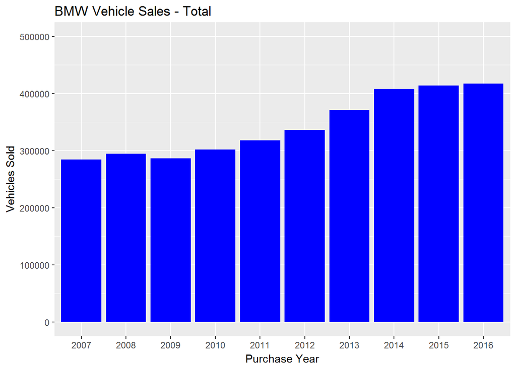

```r
options(scipen=3) #to show the y values as full numbers vs scientific (0e+00, 1e+05, etc)
ggplot(SalesNewUsed, aes(x=PurYear)) +
  geom_histogram(stat="count", fill="blue") +
  scale_y_continuous(limits = c(0,500000)) +
  labs(title="BMW Vehicle Sales - Total", x="Purchase Year", y="Vehicles Sold")
```

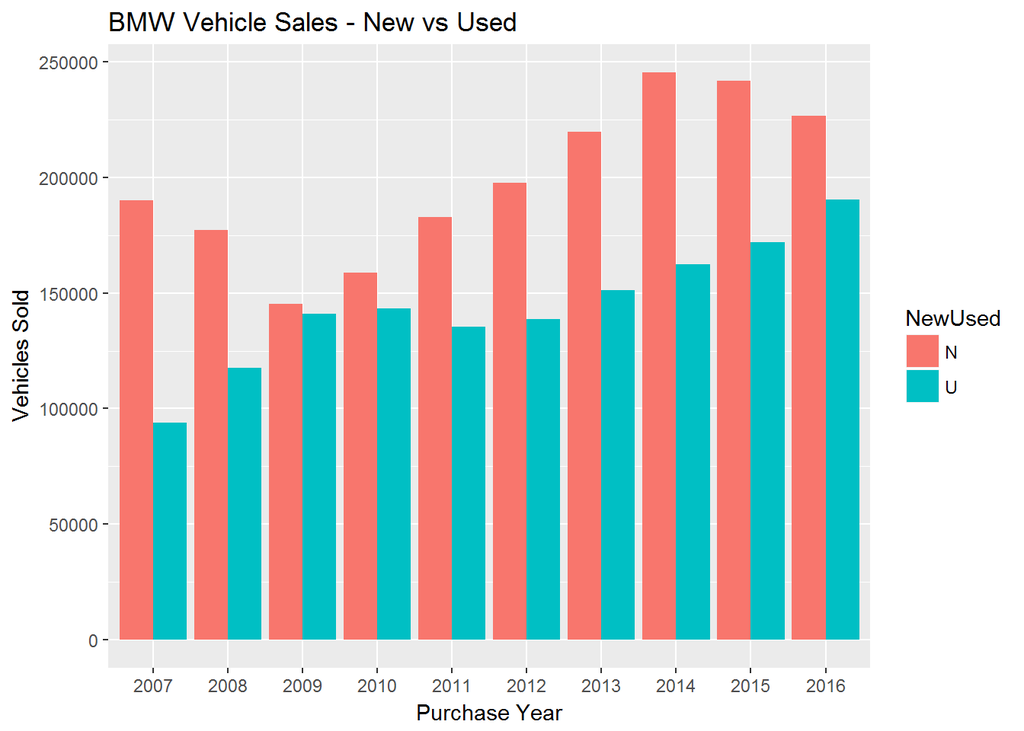

```r
ggplot(SalesNewUsed, aes(x=PurYear, fill=NewUsed)) +
  geom_histogram(stat="count", position = "dodge") +
  labs(title="BMW Vehicle Sales - New vs Used", x="Purchase Year", y="Vehicles Sold")
```

We can see that BMW sales climbed between 2011 and 2014, but have once again steadied out. In regards to New vs Used, in 2009 the sales of New and Used were almost equal with New sales at their lowest during this 10-year period. From that point on; however, Used sales were fairly steady with New sales climbing rapidly. It’s only in the last year or two do we see that Used sales are climbing again and New are on a decline. We saw this same occurrence from 2007 to 2009. This could point to the economy valuing Used or perhaps that their CPO (Certified Pre-Owned) program has become more appealing in recent years and has started to impact their New vehicle sales. On the plus side, total sales are still at their highest.

Let’s now take a look at some Regional data. We start by looking at total sales by region.

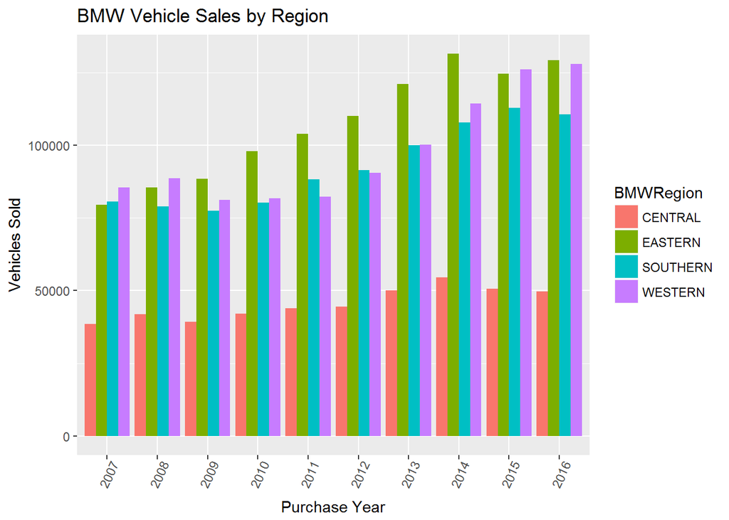

```r
ggplot(SalesNewUsed, aes(x=PurYear, fill=BMWRegion)) +
  geom_histogram(stat="count", position = "dodge") +
  theme(axis.text.x = element_text(angle=65, vjust=0.6)) +
  labs(title="BMW Vehicle Sales by Region", x="Purchase Year", y="Vehicles Sold")
```

It’s clear here that the Central region only accounts for a small portion of the sales. It’s only around 50% of any of the other three Regions. Let’s stack these bars to get an idea of each regions percentage of the annual total. Perhaps this will help us get a better visualization of how they compare.

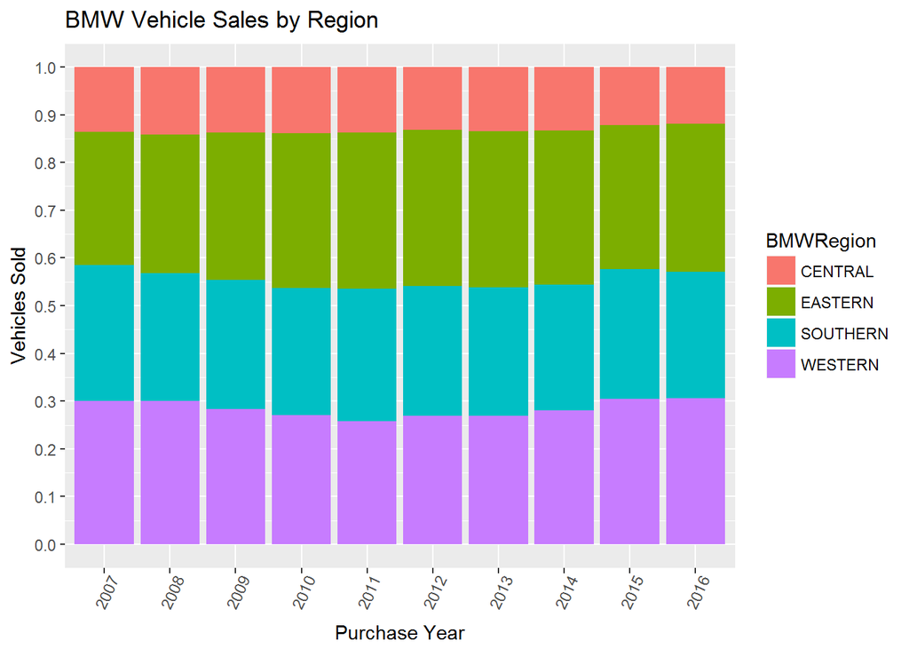

```r
ggplot(SalesNewUsed, aes(x=PurYear, fill=BMWRegion)) +
  geom_histogram(stat="count", position="fill") + # vs "stack"
  scale_y_continuous(breaks=seq(0, 1, .1)) + #c(0,.1, .2, .3, .4, .5, .6, .7, .8, .9, 1.00)) +
  theme(axis.text.x = element_text(angle=65, vjust=0.6)) +
  labs(title="BMW Vehicle Sales by Region", x="Purchase Year", y="Vehicles Sold")
```

So looking at this graph, we can see that each region is fairly consistent with it’s contribution to sales over the years. The Western & Southern regions appear to pull in between 25% & 30%, with the Eastern region typically pulling ahead slightly with 25-35% of sales. The Central region by far is the notable region with sales always under 15%. It’s clear from this plot that it’s this region that could benefit from more specific marketing efforts.

Now let’s look at the Regional sales for New vs Used.

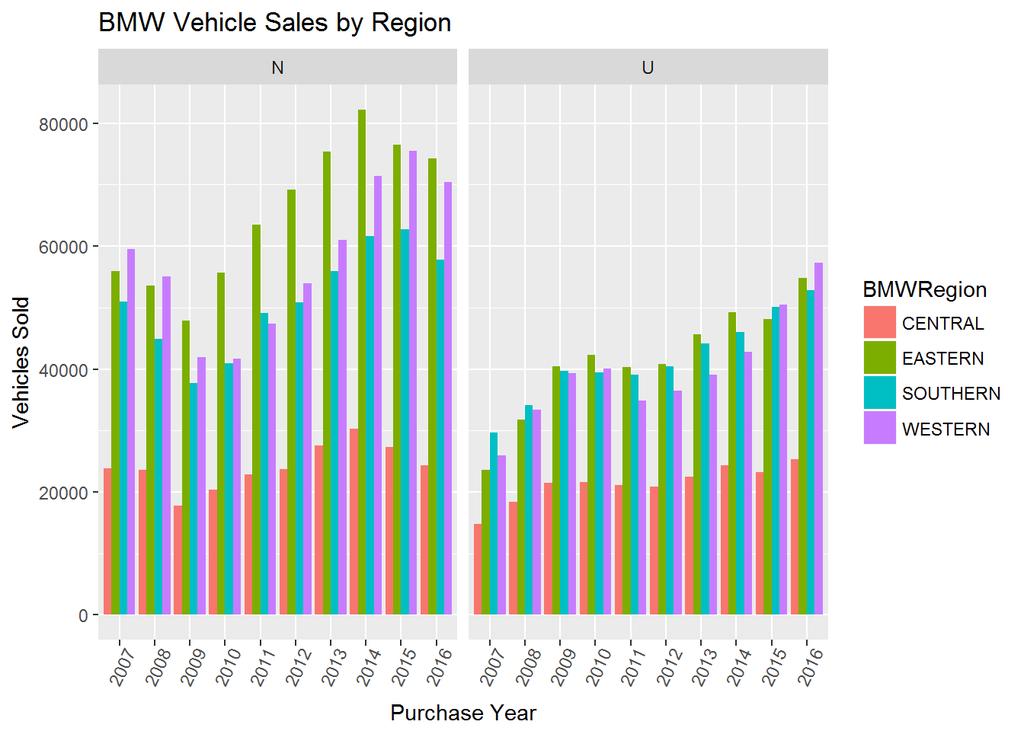

```r
ggplot(SalesNewUsed, aes(x=PurYear, fill=BMWRegion)) +
  geom_histogram(stat="count", position = "dodge") +
  facet_grid(. ~ NewUsed) +
  theme(axis.text.x = element_text(angle=65, vjust=0.6)) +
  labs(title="BMW Vehicle Sales by Region", x="Purchase Year", y="Vehicles Sold")
```

Here we can observe that even within each region, we’re seeing a similar curve that we saw with each of the New and Used sales graphs. We see that the Eastern Region generally takes the lead in both categories. However, we can also see that the Eastern Region’s lead over the Southern & Western regions in total sales between 2010 and 2014 can be accounted for in nearly all New purchases. Their edge over the Southern & Western regions in Used sales is very minor. The Eastern region saw a decline in their New sales between 2014 and 2015 though, while the Southern & Western regions continued to climb. 2016 continued to result in a decline in New sales for each region, but this was offset by the increase in Used sales for each. BMW should refocus their efforts on selling New vehicles to try to turn around their declining trend, while trying to leverage their recent increase in Used sales.

## Pitfalls of the data set

- Not all BMW stores have provided access to their Sales data so the analysis is limited by dealership participation.
- Due to possible changes in the system that a dealer uses to manage their database, the CustomerID’s can change over time. This means that a single customer may actually have more than one CustomerID and be seen as 2 or more unique customers. More elaborate customer matching, based on name & address, could be done to try to remedy some of these issue, but there is still room for error based on how a name or address is typed into the system. For example, “Jim” vs “James” or “1234 Main Street” vs “1234 Main St.”. We will also not see if the same customer purchases as more than one BMW dealership.
- And, finally, we are not going to see all sales made to all non-BMW dealerships as well as private sales. These can skew the model by not reflecting the proper length of ownership.